# P4作业——红酒质量探索与分析

# 双变量分析

## 探索中观察到的一些关系，这些特性与其他特性有何区别

游离二氧化硫与总二氧化硫呈现较强的线性相关性（0.672237671），之前我们根据名字猜测两者是包含关系，测试结果符合我们之前的预期。

密度与多个成分都有较为明显的关系，大部分是正相关，与酒精呈现负相关。通过上网查询发现，酒精密度0.789g/cm<sup>3，低于所有酒类样本的密度值（最小值0.9915g/cm</sup>3），这就很好地解释了为什么酒精含量越多，样品密度越小。我们还可以猜测到的是，另外与密度成正相关的成分，平均密度应该都大于酒类样本密度。

品质与硫酸盐、酒精含量存在比较明显正相关，与挥发性酸有负相关，查询后得知[大力猛击我](http://blog.sina.com.cn/s/blog_6715e4960100qmbr.html)，挥发性酸的味道正是葡萄酒中所谓“瑕疵”的来源。

氢离子与密度、非挥发性酸、柠檬酸呈现明显正相关，与挥发性酸更多呈现负相关，这与之前预计有一定出入。

## 是否观察到主要特性于其他特性之间的有趣联系

最大的“惊喜”来自于氢离子密度并非与三种酸类成分全部呈现正相关，与挥发性酸之间是负相关关系，这背后的原因也许需要更加专业的解释。

## 最强的关系是什么

最强相关来自于氢离子浓度与非挥发性酸，线性相关系数为0.7164。

# 多变量绘图

## 品质分数与主要相关成分之间的关系

之前的研究已经发现，品质与硫酸盐和酒精含量有较强的正相关性，与挥发性算有明显的负相关性，下面我们对不同品质的样本各因素做一次探索。

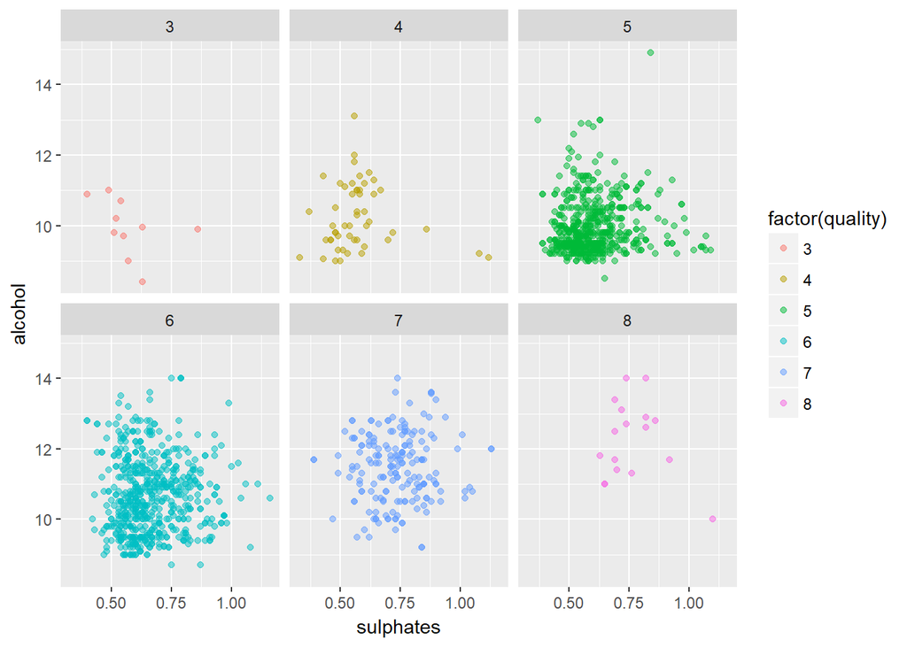

```r
# scatter plot of sulphates vs. alcohol from collections of different qualities
ggplot(aes(x = sulphates, y = alcohol), data = tidy.wine) +
  geom_point(aes(color = factor(quality)), alpha = 0.5) +
  scale_fill_brewer(palette = 'Reds') +
  facet_wrap(~quality)
```

```r
# get mean values from different quality collections
summary(subset(tidy.wine, quality == 3))[4, c(8, 6, 7)]
```

```
##            quality          sulphates            alcohol
##      "Mean   :3  " "Mean   :0.5700  " "Mean   : 9.955  "
```

```r
summary(subset(tidy.wine, quality == 4))[4, c(8, 6, 7)]
```

```
##            quality          sulphates            alcohol
##      "Mean   :4  " "Mean   :0.5696  "  "Mean   :10.26  "
```

```r
summary(subset(tidy.wine, quality == 5))[4, c(8, 6, 7)]
```

```
##            quality          sulphates            alcohol
##      "Mean   :5  " "Mean   :0.5983  " "Mean   : 9.923  "
```

```r
summary(subset(tidy.wine, quality == 6))[4, c(8, 6, 7)]
```

```
##           quality         sulphates           alcohol
##     "Mean   :6  " "Mean   :0.664  " "Mean   :10.65  "
```

```r
summary(subset(tidy.wine, quality == 7))[4, c(8, 6, 7)]
```

```
##            quality          sulphates            alcohol
##      "Mean   :7  " "Mean   :0.7368  "  "Mean   :11.48  "
```

```r
summary(subset(tidy.wine, quality == 8))[4, c(8, 6, 7)]
```

```
##            quality          sulphates            alcohol
##      "Mean   :8  " "Mean   :0.7647  "  "Mean   :12.23  "
```

从上面分析大致可以分辨出：低级别的样本比较集中在左下角，即硫酸盐和酒精含量都较低的区域，高级别的酒相比之下更靠近右上角，即硫酸盐和酒精含量都较高的区域。

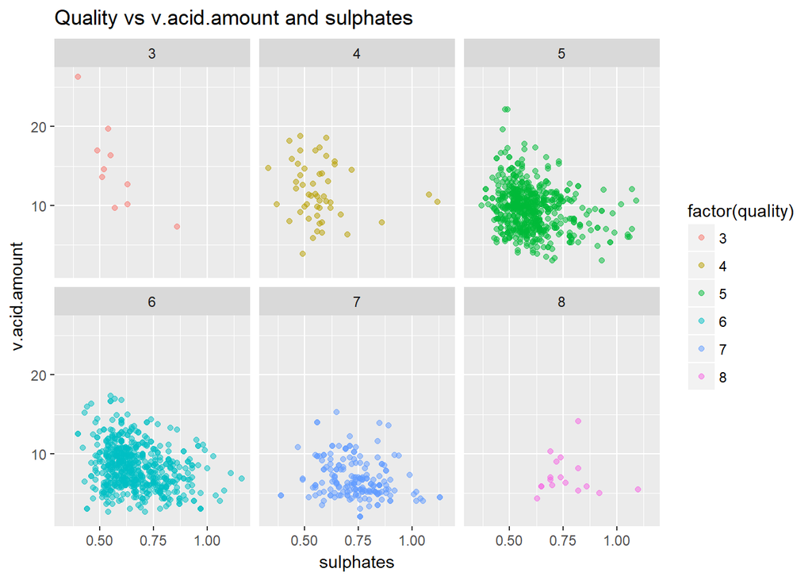

```r
ggplot(aes(x = sulphates, y = v.acid.amount), data = tidy.wine) +
  geom_point(aes(color = factor(quality)), alpha = 0.5) +
  facet_wrap(~quality) +
  ggtitle('Quality vs v.acid.amount and sulphates')
```

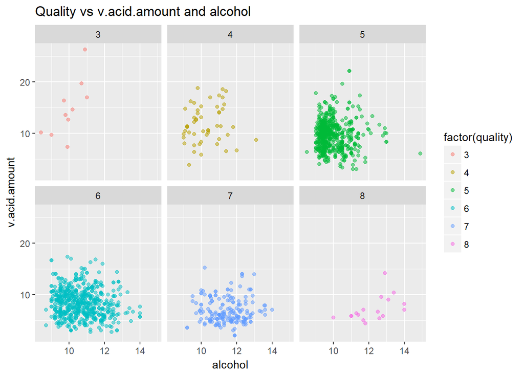

```r
ggplot(aes(x = alcohol, y = v.acid.amount), data = tidy.wine) +
  geom_point(aes(color = factor(quality)), alpha = 0.5) +
  facet_wrap(~quality) +
  ggtitle('Quality vs v.acid.amount and alcohol')
```

同样的趋势在后两幅图也可以看出来：与酒精、硫酸盐正相关，与挥发性酸负相关。

# 多变量分析

## 观察到的关系，是否存在相互促进的特性

通过数据分析了酒的品质与两个正相关成分（硫酸盐和酒精含量）之间的关系，发现较高品质分数的样本，这两类成分含量较高；较低品质的样本，这两类成分含量较低。

## 是否有联系

同上。

## 是否有数据模型，优缺点（可选）

将氢离子浓度建模为密度、非挥发性酸、挥发性酸、柠檬酸的线性模型进行分析。

```r
library(memisc)
# build models about H.concentration against 4 viariables

model1 <- lm(H.concentration ~ density + 1, data = tidy.wine)
model2 <- lm(H.concentration ~ density + f.acid.amount + 1, data = tidy.wine)
model3 <- lm(H.concentration ~ density + f.acid.amount + c.acid.amount + 1, data = tidy.wine)
model4 <- lm(H.concentration ~ density + f.acid.amount + c.acid.amount + v.acid.amount + 1, data = tidy.wine)

summary(model1)
```

```
##
## Call:
## lm(formula = H.concentration ~ density + 1, data = tidy.wine)
##
## Residuals:
##        Min         1Q     Median         3Q        Max
## -3.770e-04 -1.058e-04 -2.298e-05  8.965e-05  9.907e-04
##
## Coefficients:
##              Estimate Std. Error t value Pr(>|t|)
## (Intercept) -0.031154   0.002309  -13.49   <2e-16 ***
## density      0.031767   0.002317   13.71   <2e-16 ***
## ---
## Signif. codes:  0 '***' 0.001 '**' 0.01 '*' 0.05 '.' 0.1 ' ' 1
##
## Residual standard error: 0.0001645 on 1497 degrees of freedom
## Multiple R-squared:  0.1116, Adjusted R-squared:  0.111
## F-statistic:   188 on 1 and 1497 DF,  p-value: < 2.2e-16
```

```r
summary(model2)
```

```
##
## Call:
## lm(formula = H.concentration ~ density + f.acid.amount + 1, data = tidy.wine)
##
## Residuals:
##        Min         1Q     Median         3Q        Max
## -3.488e-04 -7.190e-05 -1.456e-05  5.557e-05  6.409e-04
##
## Coefficients:
##                 Estimate Std. Error t value Pr(>|t|)
## (Intercept)    2.480e-02  2.196e-03   11.29   <2e-16 ***
## density       -2.513e-02  2.216e-03  -11.34   <2e-16 ***
## f.acid.amount  1.361e-05  3.550e-07   38.33   <2e-16 ***
## ---
## Signif. codes:  0 '***' 0.001 '**' 0.01 '*' 0.05 '.' 0.1 ' ' 1
##
## Residual standard error: 0.0001169 on 1496 degrees of freedom
## Multiple R-squared:  0.5518, Adjusted R-squared:  0.5512
## F-statistic: 920.9 on 2 and 1496 DF,  p-value: < 2.2e-16
```

```r
summary(model3)
```

```
##
## Call:
## lm(formula = H.concentration ~ density + f.acid.amount + c.acid.amount +
##     1, data = tidy.wine)
##
## Residuals:
##        Min         1Q     Median         3Q        Max
## -3.484e-04 -7.230e-05 -1.529e-05  5.497e-05  6.408e-04
##
## Coefficients:
##                 Estimate Std. Error t value Pr(>|t|)
## (Intercept)    2.471e-02  2.230e-03   11.08   <2e-16 ***
## density       -2.504e-02  2.252e-03  -11.12   <2e-16 ***
## f.acid.amount  1.354e-05  4.608e-07   29.39   <2e-16 ***
## c.acid.amount  9.839e-07  4.276e-06    0.23    0.818
## ---
## Signif. codes:  0 '***' 0.001 '**' 0.01 '*' 0.05 '.' 0.1 ' ' 1
##
## Residual standard error: 0.0001169 on 1495 degrees of freedom
## Multiple R-squared:  0.5518, Adjusted R-squared:  0.5509
## F-statistic: 613.6 on 3 and 1495 DF,  p-value: < 2.2e-16
```

```r
summary(model4)
```

```
##
## Call:
## lm(formula = H.concentration ~ density + f.acid.amount + c.acid.amount +
##     v.acid.amount + 1, data = tidy.wine)
##
## Residuals:
##        Min         1Q     Median         3Q        Max
## -3.485e-04 -7.214e-05 -1.540e-05  5.507e-05  6.439e-04
##
## Coefficients:
##                 Estimate Std. Error t value Pr(>|t|)
## (Intercept)    2.532e-02  2.286e-03  11.079   <2e-16 ***
## density       -2.567e-02  2.311e-03 -11.107   <2e-16 ***
## f.acid.amount  1.353e-05  4.609e-07  29.351   <2e-16 ***
## c.acid.amount  4.280e-06  5.068e-06   0.845    0.398
## v.acid.amount  1.580e-06  1.304e-06   1.212    0.226
## ---
## Signif. codes:  0 '***' 0.001 '**' 0.01 '*' 0.05 '.' 0.1 ' ' 1
##
## Residual standard error: 0.0001169 on 1494 degrees of freedom
## Multiple R-squared:  0.5523, Adjusted R-squared:  0.5511
## F-statistic: 460.7 on 4 and 1494 DF,  p-value: < 2.2e-16
```

从模型结果来看，最好的情况下，R^2只能达到约0.55，说明还有潜在因素未被发掘，或者模型不太合适。

# 最终成图与汇总

## 酒的品质与主要相关变量的关系

通过分析发现，品质与硫酸盐和酒精含量有较强的正相关性，与挥发性算有明显的负相关性。具体分布如下：

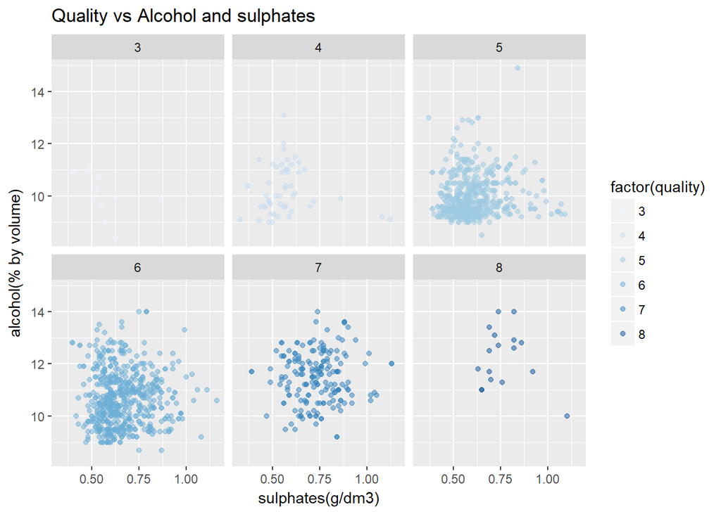

```r
ggplot(aes(x = sulphates, y = alcohol), data = tidy.wine) +
  geom_point(aes(color = factor(quality)), alpha = 0.5) +
  facet_wrap(~quality) +
  scale_color_brewer(palette  = "Blues") +
  ggtitle('Quality vs Alcohol and sulphates') +
  labs(x = 'sulphates(g/dm3)',
       y = 'alcohol(% by volume)')
```

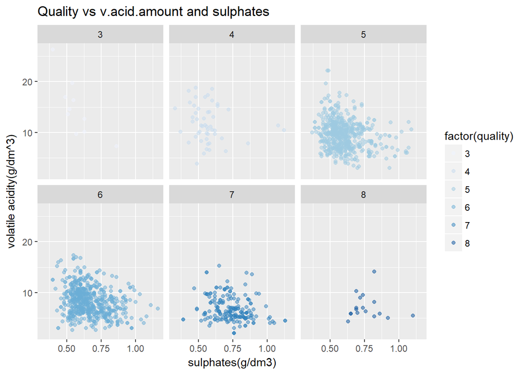

```r
ggplot(aes(x = sulphates, y = v.acid.amount), data = tidy.wine) +
  geom_point(aes(color = factor(quality)), alpha = 0.5) +
  facet_wrap(~quality) +
  scale_color_brewer(palette  = "Blues") +
  ggtitle('Quality vs v.acid.amount and sulphates') +
  labs(x = 'sulphates(g/dm3)',
       y = 'volatile acidity(g/dm^3)')
```

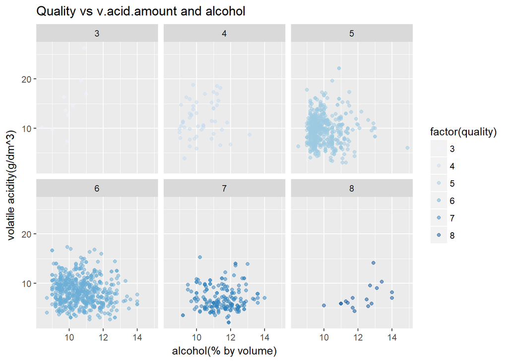

```r
ggplot(aes(x = alcohol, y = v.acid.amount), data = tidy.wine) +
  geom_point(aes(color = factor(quality)), alpha = 0.5) +
  facet_wrap(~quality) +
  scale_color_brewer(palette  = "Blues") +
  ggtitle('Quality vs v.acid.amount and alcohol') +
  labs(x = 'alcohol(% by volume)',
       y = 'volatile acidity(g/dm^3)')
```

从三幅图中得到的结论是：随着酒的品质的提高，酒精含量和硫酸盐含量趋于上升，而挥发性酸含量趋于下降。

# 反思

从整个分析过程来看，成功之处在于：按照流程从简单到深入一步步走，还是得出来一些有用的结论；主要遇到的难点在于：由于并非食品或化学专业背景出身，这个数据集在我眼中变量之间的自然关联不够清晰，不能预先想好内在联系，然后引导分析工作的开展，只能走一步得出一个结论。比如针对氢离子含量分析一节中，本来预想的是氢离子浓度应该与各种酸含量呈现较强的正相关性，但是可能由于各化学成分之间复杂的关系，也许有相互抑制等等作用，使得模型出来的效果不佳，最重要的是，当前对于我而言似乎没有特别好的办法解决。

我认为数据分析除了直接揭露数据明面上包含的关系之外，还应该能够帮助发现背后的规律，但是看来往往还需要很多背景知识的获取以及累积。

后续要继续这个课题研究的话，希望能够深入探讨氢离子浓度的决定因素，通过更好的模型（不一定是线性模型），给出各因素更加精确的影响程度量化值：不同酸的正向影响程度应该可以反映电离程度的差异，而负的影响则可能表明相互抑制的作用。